# Reproducible Science & Figures Assignment

2024-12-09

## QUESTION 01: Data Visualisation for Science Communication

**Loading libraries**

```r
renv::restore()
```

```
## - The library is already synchronized with the lockfile.
```

```r
library(tidyverse)
library(palmerpenguins)
library(janitor)
library(ragg)
library(here)
library(svglite)
library(broom)
```

**Loading and saving raw data set**

```r
penguins_raw
```

```
## # A tibble: 344 × 17
##    studyName `Sample Number` Species         Region Island Stage `Individual ID`
##    <chr>               <dbl> <chr>           <chr>  <chr>  <chr> <chr>
##  1 PAL0708                 1 Adelie Penguin… Anvers Torge… Adul… N1A1
##  2 PAL0708                 2 Adelie Penguin… Anvers Torge… Adul… N1A2
##  3 PAL0708                 3 Adelie Penguin… Anvers Torge… Adul… N2A1
##  4 PAL0708                 4 Adelie Penguin… Anvers Torge… Adul… N2A2
##  5 PAL0708                 5 Adelie Penguin… Anvers Torge… Adul… N3A1
##  6 PAL0708                 6 Adelie Penguin… Anvers Torge… Adul… N3A2
##  7 PAL0708                 7 Adelie Penguin… Anvers Torge… Adul… N4A1
##  8 PAL0708                 8 Adelie Penguin… Anvers Torge… Adul… N4A2
##  9 PAL0708                 9 Adelie Penguin… Anvers Torge… Adul… N5A1
## 10 PAL0708                10 Adelie Penguin… Anvers Torge… Adul… N5A2
## # ℹ 334 more rows
## # ℹ 10 more variables: `Clutch Completion` <chr>, `Date Egg` <date>,
## #   `Culmen Length (mm)` <dbl>, `Culmen Depth (mm)` <dbl>,
## #   `Flipper Length (mm)` <dbl>, `Body Mass (g)` <dbl>, Sex <chr>,
## #   `Delta 15 N (o/oo)` <dbl>, `Delta 13 C (o/oo)` <dbl>, Comments <chr>
```

```r
write_csv(penguins_raw, here("data", "penguins_raw.csv"))
```

**Loading functions**

```r
source(here("functions", "Functions_For_Penguins.R"))
```

**Cleaning the raw data and saving as a new data file**

```r
#clean data
penguins_cleaned <- penguins_raw %>%
  clean_column_names() %>%
  remove_columns("comments") %>%
  remove_columns("delta") %>%
  remove_empty_columns_rows() %>%
  shorten_species() %>%
  shorten_sex ()

#save and load clean data
write_csv(penguins_cleaned, here("data", "penguins_clean.csv"))

penguins_cleaned <- read_csv(here("data", "penguins_clean.csv"), show_col_types = FALSE)

#visualise the cleaned data
colnames(penguins_cleaned)
```

```
##  [1] "study_name"        "sample_number"     "species"
##  [4] "region"            "island"            "stage"
##  [7] "individual_id"     "clutch_completion" "date_egg"
## [10] "culmen_length_mm"  "culmen_depth_mm"   "flipper_length_mm"
## [13] "body_mass_g"       "sex"
```

```r
penguins_cleaned
```

```
## # A tibble: 344 × 14
##    study_name sample_number species region island    stage         individual_id
##    <chr>              <dbl> <chr>   <chr>  <chr>     <chr>         <chr>
##  1 PAL0708                1 Adelie  Anvers Torgersen Adult, 1 Egg… N1A1
##  2 PAL0708                2 Adelie  Anvers Torgersen Adult, 1 Egg… N1A2
##  3 PAL0708                3 Adelie  Anvers Torgersen Adult, 1 Egg… N2A1
##  4 PAL0708                4 Adelie  Anvers Torgersen Adult, 1 Egg… N2A2
##  5 PAL0708                5 Adelie  Anvers Torgersen Adult, 1 Egg… N3A1
##  6 PAL0708                6 Adelie  Anvers Torgersen Adult, 1 Egg… N3A2
##  7 PAL0708                7 Adelie  Anvers Torgersen Adult, 1 Egg… N4A1
##  8 PAL0708                8 Adelie  Anvers Torgersen Adult, 1 Egg… N4A2
##  9 PAL0708                9 Adelie  Anvers Torgersen Adult, 1 Egg… N5A1
## 10 PAL0708               10 Adelie  Anvers Torgersen Adult, 1 Egg… N5A2
## # ℹ 334 more rows
## # ℹ 7 more variables: clutch_completion <chr>, date_egg <date>,
## #   culmen_length_mm <dbl>, culmen_depth_mm <dbl>, flipper_length_mm <dbl>,
## #   body_mass_g <dbl>, sex <chr>
```

**Creating a figure using the Palmer Penguin data set that is correct but badly communicates the data**

```
## # A tibble: 342 × 3
##    species flipper_length_mm body_mass_g
##    <chr>               <dbl>       <dbl>
##  1 Adelie                181        3750
##  2 Adelie                186        3800
##  3 Adelie                195        3250
##  4 Adelie                193        3450
##  5 Adelie                190        3650
##  6 Adelie                181        3625
##  7 Adelie                195        4675
##  8 Adelie                193        3475
##  9 Adelie                190        4250
## 10 Adelie                186        3300
## # ℹ 332 more rows
```

#### a) Figure:

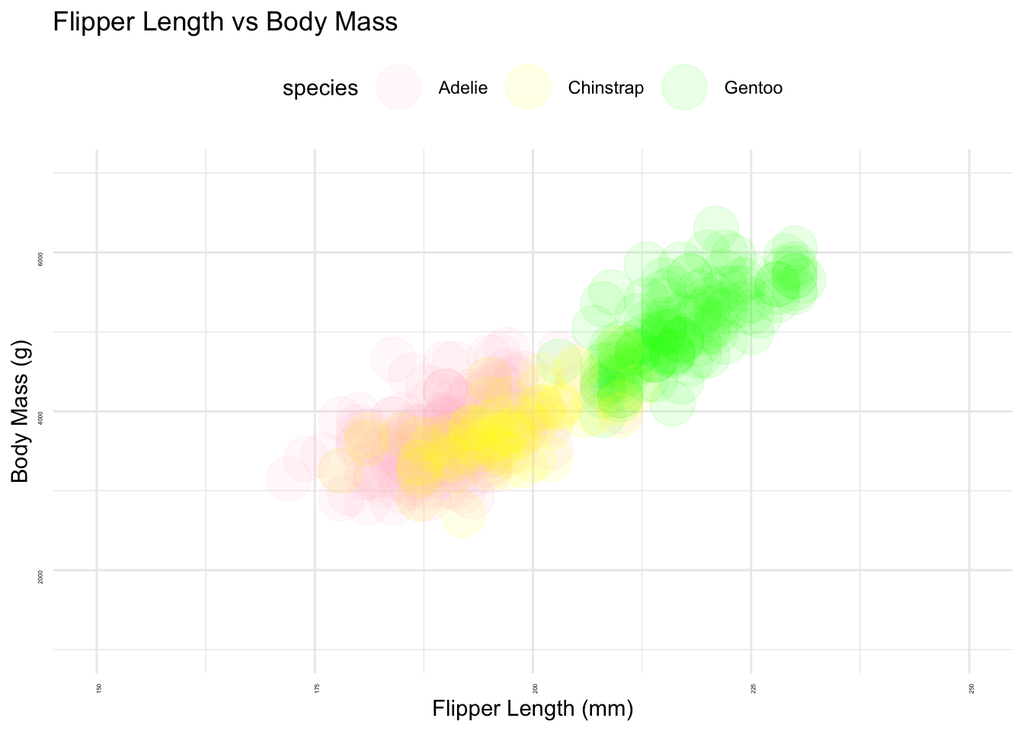

## QUESTION 2: Data Pipeline

### Introduction

Sexual size dimorphism is a trait exhibited by many vertebrate species as a result of selective forces acting differently on males and females due to their differing reproductive and ecological roles. This trend has been found to be true in penguins, particularly in differing flipper lengths with males having larger flippers than females (Jennings et al., 2016). This study will investigate sexual size dimorphism in the Adelie species of penguin by testing whether males have larger flipper lengths than females using. a linear model analysis of the ‘Palmer Penguins’ data set. If there is no sexual size dimorphism in this species, we would expect that the null hypothesis that there is no significant difference in flipper length between males and females to be true . This would mean that the coefficient of the linear model analysis would not be statistically different from zero. If the coefficient of the linear model analysis *is* statistically different from zero, we can reject this null hypothesis and this would support the alternate hypothesis that sexual size dimorphism in flippers does occur in Adelie penguins.

### Statistical Method

**Loading libraries**

```r
renv::restore
```

[output not shown]

[output cut: 22 more lines]

[output not shown]

```r
library(tidyverse)
library(palmerpenguins)
library(janitor)
library(ragg)
library(here)
library(svglite)
library(broom)
```

**Loading and saving raw data set**

```r
penguins_raw
```

```
## # A tibble: 344 × 17
##    studyName `Sample Number` Species         Region Island Stage `Individual ID`
##    <chr>               <dbl> <chr>           <chr>  <chr>  <chr> <chr>
##  1 PAL0708                 1 Adelie Penguin… Anvers Torge… Adul… N1A1
##  2 PAL0708                 2 Adelie Penguin… Anvers Torge… Adul… N1A2
##  3 PAL0708                 3 Adelie Penguin… Anvers Torge… Adul… N2A1
##  4 PAL0708                 4 Adelie Penguin… Anvers Torge… Adul… N2A2
##  5 PAL0708                 5 Adelie Penguin… Anvers Torge… Adul… N3A1
##  6 PAL0708                 6 Adelie Penguin… Anvers Torge… Adul… N3A2
##  7 PAL0708                 7 Adelie Penguin… Anvers Torge… Adul… N4A1
##  8 PAL0708                 8 Adelie Penguin… Anvers Torge… Adul… N4A2
##  9 PAL0708                 9 Adelie Penguin… Anvers Torge… Adul… N5A1
## 10 PAL0708                10 Adelie Penguin… Anvers Torge… Adul… N5A2
## # ℹ 334 more rows
## # ℹ 10 more variables: `Clutch Completion` <chr>, `Date Egg` <date>,
## #   `Culmen Length (mm)` <dbl>, `Culmen Depth (mm)` <dbl>,
## #   `Flipper Length (mm)` <dbl>, `Body Mass (g)` <dbl>, Sex <chr>,
## #   `Delta 15 N (o/oo)` <dbl>, `Delta 13 C (o/oo)` <dbl>, Comments <chr>
```

```r
write_csv(penguins_raw, here("data", "penguins_raw.csv"))
```

**Loading functions**

```r
source(here("functions", "Functions_For_Penguins.R"))
source(here("functions", "Exploratory_Plotting.R"))
source(here("functions", "Diagnostic_Plot_Function.R"))
source(here("functions", "SaveAs_svg_png_Functions.R"))
```

**Cleaning the raw data and saving as a new data files**

```r
#clean data
penguins_cleaned <- penguins_raw %>%
  clean_column_names() %>%
  remove_columns("comments") %>%
  remove_columns("delta") %>%
  remove_empty_columns_rows() %>%
  shorten_species() %>%
  shorten_sex ()

#save and load clean data
write_csv(penguins_cleaned, here("data", "penguins_clean.csv"))

penguins_cleaned <- read_csv(here("data", "penguins_clean.csv"), show_col_types = FALSE)

#visualise the cleaned data
colnames(penguins_cleaned)
```

```
##  [1] "study_name"        "sample_number"     "species"
##  [4] "region"            "island"            "stage"
##  [7] "individual_id"     "clutch_completion" "date_egg"
## [10] "culmen_length_mm"  "culmen_depth_mm"   "flipper_length_mm"
## [13] "body_mass_g"       "sex"
```

```r
penguins_cleaned
```

```
## # A tibble: 344 × 14
##    study_name sample_number species region island    stage         individual_id
##    <chr>              <dbl> <chr>   <chr>  <chr>     <chr>         <chr>
##  1 PAL0708                1 Adelie  Anvers Torgersen Adult, 1 Egg… N1A1
##  2 PAL0708                2 Adelie  Anvers Torgersen Adult, 1 Egg… N1A2
##  3 PAL0708                3 Adelie  Anvers Torgersen Adult, 1 Egg… N2A1
##  4 PAL0708                4 Adelie  Anvers Torgersen Adult, 1 Egg… N2A2
##  5 PAL0708                5 Adelie  Anvers Torgersen Adult, 1 Egg… N3A1
##  6 PAL0708                6 Adelie  Anvers Torgersen Adult, 1 Egg… N3A2
##  7 PAL0708                7 Adelie  Anvers Torgersen Adult, 1 Egg… N4A1
##  8 PAL0708                8 Adelie  Anvers Torgersen Adult, 1 Egg… N4A2
##  9 PAL0708                9 Adelie  Anvers Torgersen Adult, 1 Egg… N5A1
## 10 PAL0708               10 Adelie  Anvers Torgersen Adult, 1 Egg… N5A2
## # ℹ 334 more rows
## # ℹ 7 more variables: clutch_completion <chr>, date_egg <date>,
## #   culmen_length_mm <dbl>, culmen_depth_mm <dbl>, flipper_length_mm <dbl>,
## #   body_mass_g <dbl>, sex <chr>
```

```r
# Saving dataset of Adelie penguins, flipper length & sex
adelie_flipper_length_and_sex <- penguins_cleaned %>%
  select(species, flipper_length_mm, sex) %>%
  filter(species == "Adelie") %>%
  drop_na()

write_csv(adelie_flipper_length_and_sex, here("data", "adelie_flipper_length_and_sex.csv"))
```

**Exploratory plot of raw data**

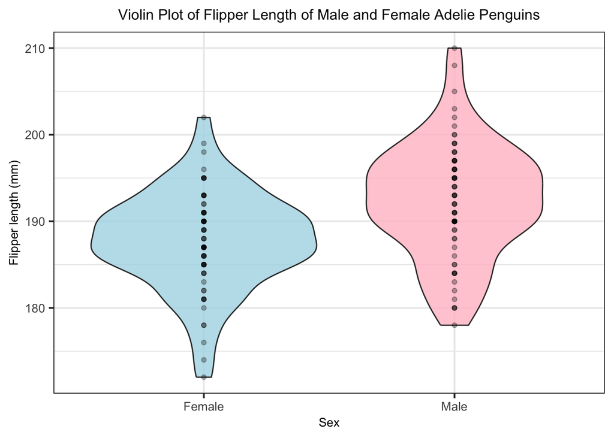

```r
# using exploratory plotting function generate violin plot
plot_flipper_violin(adelie_flipper_length_and_sex)
```

```r
# Saving the plot as a PNG file in figures folder
save_flipper_violin_png(
  penguins_flippers = adelie_flipper_length_and_sex,
  filename = "Figures/adelie_flipper_violin_plot.png",
  size = 15,
  res = 300,
  scaling = 1
)
```

```r
# Saving the plot as an SVG file in figures folder
save_flipper_plot_svg(
  penguins_flippers = adelie_flipper_length_and_sex,
  filename = "Figures/adelie_flipper_violin_plot.svg",
  size = 15,
  scaling = 1
)
```

The violin plot above visualises the flipper length data for males and females of the Adelie penguin species. From the shape of these plots, we can see that the flipper length of males being on average larger than that of the females. The data for both males and females appears approximately normally distributed, with a slight positive skew for the male flipper length data as the lower end of the violin is wider than the top end.

**Defining the linear model**

```r
linear_model <- lm(flipper_length_mm ~ sex, data = adelie_flipper_length_and_sex)
```

**Checking data meets assumptions of linear model analysis**

Before conducting the linear model analysis we first verify that the data meets the assumptions of a linear model analysis. These are; independence of data points, normality, homoscedasticity, and absence of influential outliers. We can assume that the data collection and sampling methods used ensured independence of data points. To test for compliance with the remaining assumptions, diagnostic plots are used to examine the data.

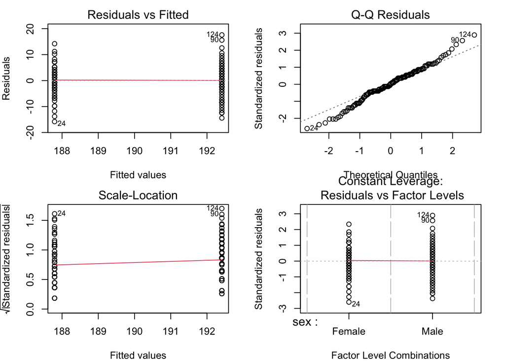

```r
#Diagnostic plots
#Displaying diagnostic plots in a grid
par(mfrow = c(2, 2),
    mar = c(4, 4, 2, 2))


# Running diagnostic plot function
Diagnostic_Plot_Function()
```

```r
# Saving diagnostic plots as a .png
save_diagnostic_plot_as_png(
  here("figures", "Diagnostic_Plot.png"),
  Diagnostic_Plot_Function,
  size = 20,
  res = 300,
  scaling = 2
)
```

```r
# Saving diagnostic plots as a .svg
save_diagnostic_plot_as_svg(
  here("figures", "Diagnostic_Plot.svg"),
  Diagnostic_Plot_Function,
  size = 20,
  scaling = 2
)
```

The residuals versus fitted values and scale-location plot both show an approximately horizontal red line which suggests the data fits the assumption of homoscedasticity. The Q-Q residuals plot shows the points falling mostly along the diagonal line with some deviation at the extreme ends which are not sufficient to violate the assumption of normality, therefore we may assume that the residuals are normally distributed. Finally, the residuals versus factor plot indicates no significant outliers, validating the assumption of absence of influential outliers.

### Results & Discussion

**Summary of the linear model**

```r
# Viewing a summary of the linear model analysis
summary(linear_model)
```

```
##
## Call:
## lm(formula = flipper_length_mm ~ sex, data = adelie_flipper_length_and_sex)
##
## Residuals:
##      Min       1Q   Median       3Q      Max
## -15.7945  -2.7945   0.2055   3.5890  17.5890
##
## Coefficients:
##             Estimate Std. Error t value Pr(>|t|)
## (Intercept)  187.794      0.716 262.269  < 2e-16 ***
## sexMale        4.616      1.013   4.559 1.09e-05 ***
## ---
## Signif. codes:  0 '***' 0.001 '**' 0.01 '*' 0.05 '.' 0.1 ' ' 1
##
## Residual standard error: 6.118 on 144 degrees of freedom
## Multiple R-squared:  0.1261, Adjusted R-squared:  0.1201
## F-statistic: 20.78 on 1 and 144 DF,  p-value: 1.09e-05
```

**Plotted linear model**

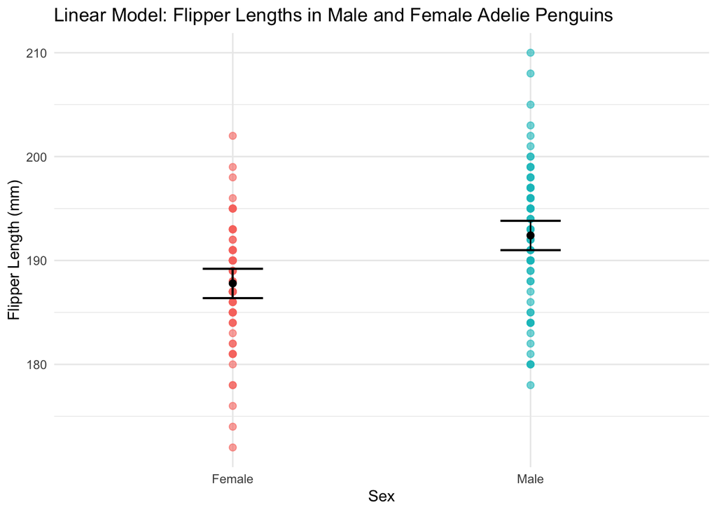

```r
# Creating dataframe with the model confidence intervals
model_predictions <- adelie_flipper_length_and_sex %>%
  mutate(
    predicted = predict(linear_model, newdata = adelie_flipper_length_and_sex),
    conf_low = predict(linear_model, newdata = adelie_flipper_length_and_sex, interval = "confidence")[,2],
    conf_high = predict(linear_model, newdata = adelie_flipper_length_and_sex, interval = "confidence")[,3]
  )

# Plotting the model
plot <- ggplot(model_predictions, aes(x = sex, y = flipper_length_mm)) +
  geom_point(aes(color = sex), size = 2, alpha = 0.6) +
  geom_errorbar(aes(ymin = conf_low, ymax = conf_high), width = 0.2) +
  stat_summary(aes(x = sex, y = flipper_length_mm), fun = mean, geom = "point", color = "black", size = 2) +
  labs(title = "Linear Model: Flipper Lengths in Male and Female Adelie Penguins", x = "Sex", y = "Flipper Length (mm)") +
  theme_minimal() +
  theme(legend.position = "none")

plot
```

**Saving Plots as .svg & .png files**

```r
# Saving as PNG
save_plot_as_png(plot, "figures/Linear_Model_Plot.png", size = 20, res = 300)

# Saving as SVG
save_plot_as_svg(plot, "figures/Linear_Model_Plot.svg", size = 20)
```

**Results table**

```r
# Creating a summary of the linear model
linear_model_summary <- tidy(linear_model)

# Creating row for female (intercept) estimate & standard error
female_row <- linear_model_summary %>%
  filter(term == "(Intercept)") %>%
  mutate(
    term = "Female",
    estimate = estimate,
    std.error = std.error
  ) %>%
  select(term, estimate, std.error)

# Creating row for male estimate, standard error, t statsitic and p value
male_row <- linear_model_summary %>%
  filter(term == "sexMale") %>%
  select(term, estimate, std.error, statistic, p.value)

# Forming the full table by combining rows and formatting for better visualisation
summary_table <- bind_rows(female_row, male_row)

summary_table <- summary_table %>%
  mutate(
    estimate = round(estimate, 3),
    std.error = round(std.error, 3),
    statistic = ifelse(is.na(statistic), NA, round(statistic, 3)),
    p.value = ifelse(is.na(p.value), NA, format(p.value, scientific = TRUE, digits = 4)),
    term = recode(term, "sexMale" = "Male", "sexFemale" = "Female")
  )
```

| Term | Estimate | Standard Error | T Statistic | P Value |
| --- | --- | --- | --- | --- |
| Female | 187.795 | 0.716 | NA | NA |
| Male | 4.616 | 1.013 | 4.559 | 1.09e-05 |

From these results, the positive estimate for male Adelie penguins of 4.616 indicates that on average, males have a greater flipper length than females by 4.616mm. Additionally, the standard errors are small which indicates that the estimates are precise and the model is robust. The P value of 1.09x10⁻⁵ is less than the accepted significance level 0.05, suggesting this difference in flipper length is statistically significant and unlikely to have arisen by chance. Therefore, we have sufficient evidence to reject the null hypothesis which stated no difference in flipper length between males and females.

### Conclusion

The linear model analysis was conducted to look at the difference in flipper length between male and female Adelie penguins on the basis that this data appeared to meet the assumptions of a linear model. The results of this model indicated a statistically significant relationship at the 0.05 significance level (p-value of 1.09 × 10⁻⁵) with male penguins on average having a greater flipper length than females. This provides strong evidence for rejecting the null hypothesis that there is no difference in flipper length between sexes. This difference in flipper length may be influential in understanding the ecology or evolution of sexual dimorphism in this species of penguin. Future studies may endeavor to investigate other characteristic traits of sexual dimorphism in Adelie penguins or compare this difference in flipper length in other penguin species to determine whether they also follow this trend.

### References

- Jennings, S., Varsani, A., Dugger, K.M., Ballard, G. and Ainley, D.G. (2016). Sex-Based Differences in Adélie Penguin (Pygoscelis adeliae) Chick Growth Rates and Diet. *PLOS ONE*, 11(3), p.e0149090. doi:https://doi.org/10.1371/journal.pone.0149090.
- Whitlock, M. and Schluter, D. (2009). *The Analysis of Biological Data*. Roberts Publishers.

## QUESTION 3: Open Science

*GitHub link:* https://github.com/awesomeorangutan/Reproducible_Science

*Partner’s GitHub link:* https://github.com/The-Nedstar/ReproducableFigures

### Reflection on your experience running partner’s code

Most of the code ran smoothly when running my partner’s code, although there were a couple of issues that needed amending. The first issue I encountered was in the initialisation section at the beginning of the code when loading the packages from my library as the ‘plot3D’ package was unavailable. This appeared to be an issue with Apple Mac as this was available on their windows device, highlighting a potential issue with reproducibility on different devices. However, this package was only necessary for their code in question 1 of the assignment, so after deleting ‘library(plot3D)’ from the code this was fixed and there were no further issues relating to the code in question 2. Within the code for question 2, the comments and subheadings on each section of code made it easy to follow and understand and the code all ran without any issues. One change I would make is in improving the clarity of some variable names such as ‘penguins_MVF’. Upon first inspection of this it wasn’t completely clear what this data set was, so a more detailed name such as ‘Penguin_Mass_vs_Flippers’ could be an improvement to make this easier to follow. The use of the graph-making function found in ‘penguins.R’ within the functions file was very efficient as it created both the exploratory scatterplot graph and linear model graph within one function through use of ‘if’ commands. This and created very clear graphs and it was easy to make small adjustments such as changing the titles and labels on the graphs. This did have limitations though, as deeper and more complex changes to the graphs were very difficult to accomplish. One change I would like to have made is cropping the x axis to remove blank space (as had been done for the y axis) allowing the data points to fill a greater area of the graph, rather than being clustered on the right-hand side. This amendment involved altering the graph-making function, which was very difficult to accomplish. Therefore, it may be better to have made two separate and more simple functions for making the scatterplot and linear model plot to improve the ease of manipulating graph aspects without breaking the code.

### Reflection on my code based on experience with partner’s code and their review of mine

My partner made the following suggestions for my code:

1. Make more use of functions, for example, a function could have been used to form the male and female rows in creating the results table.

I agree with this suggestion and this is something I would change in the future, not only for creating the results table, but also potentially making a function for plotting the linear model as this would allow it to be used for analysing other variables in the dataset.

2. Fix the issue of reproducibility in my exploratory violin plot function. My function in ‘Exploratory_Plotting.R’ made a violin plot specifically for making violin plot of the flipper data for male and female Adelie penguins. In this function, the variable are already defined so it couldn’t be used for other variables in the Palmer penguins data set as you would have to alter the function.

I agree with this point, as it raises a potential issue with reproducibility if one wanted to use the function for visualising raw data of other variables. It would have been better to make a more generalised function that could be used in other contexts. This is something I would change in the future.

3. Variable names are too long and complicated. My partner highlighted that some of the names of my variables are quite long, which makes the code look over crowded and slightly messy.

I agree with this to an extent, for example ‘adelie_flipper_length_and_sex’ is quite long. However, I believe this to be an issue of personal preference. While I find that this helps my code to be more easily understood, to others it may be slightly convoluted. In future, I might think more about making my variable names both concise and clear. An improved version I could have used is ‘adelie_flipper_and_sex’ as the only data collected on flippers is their length, so including ‘length’ in the variable name may be unnecessary detailing.

Overall, through running my partner’s code and my partner running my code, I learned that when writing code for other people to use it is important to make sure that sections of the code are properly annotated and variable names are clear so that it is easy to understand and make alterations. I also realised that its not only important for the main code to be reproducible and run smoothly, but functions used within the code should be reproducible and able to be applied to other variables in the data set.